# Session 6

## Import the fpp library

library(fpp)

## Example 1: Quarterly Australian Beer production

Description

Total quarterly beer production in Australia (in megalitres) from 1956:Q1 to 2008:Q3.

See ?ausbeer for additional information

### Plot the Time-series

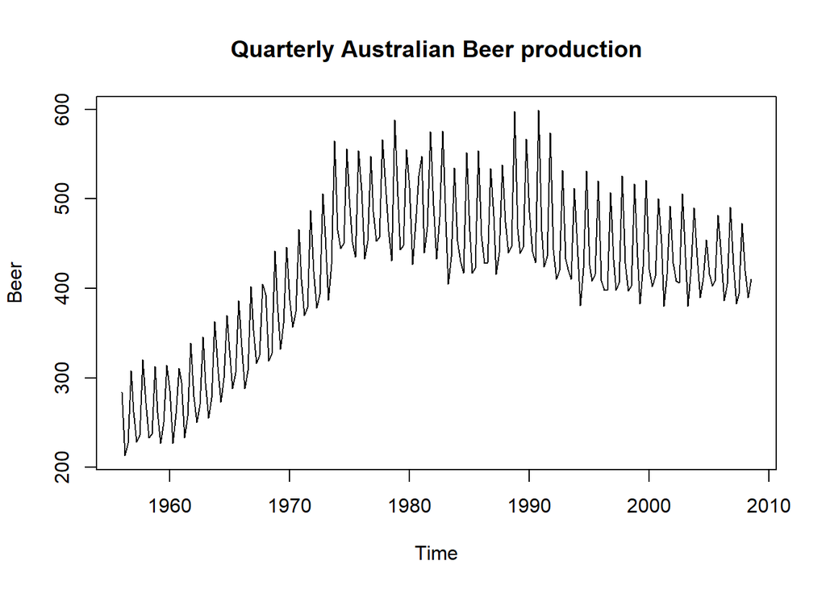

```r
plot(ausbeer,ylab='Beer',main='Quarterly Australian Beer production')
```

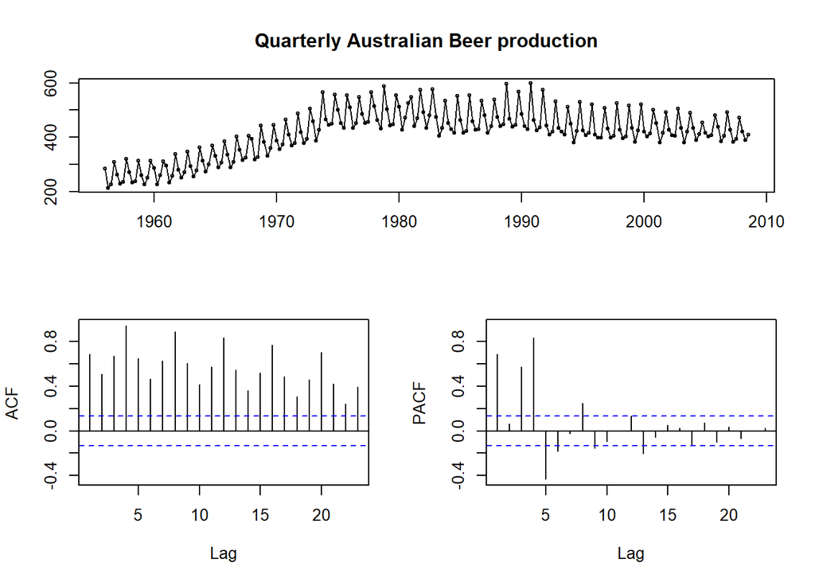

```r
tsdisplay(ausbeer,main='Quarterly Australian Beer production')
```

### Split the data

```r
beer_subset <- window(ausbeer,start=1992,end=2004)
```

#### Seasonal Difference and ACF

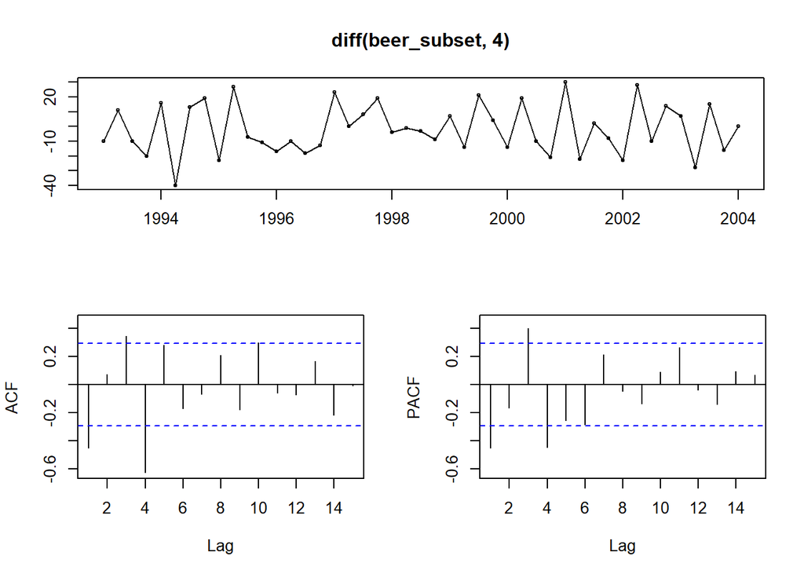

```r
tsdisplay(diff(beer_subset,4))
```

### Time series cross-validation - tsCV()

Description

tsCV computes the forecast errors obtained by applying forecastfunction to subsets of the time series y using a rolling forecast origin.

See ?tsCV for additional information

```r
model_1 <- function(x, h){forecast(Arima(x, order=c(0,0,2), seasonal =list( order=c(0, 1, 1), period=4)), h=h)}
error_1 <- tsCV(beer_subset, model_1, h=1)
error_2 <- tsCV(beer_subset, model_1, h=1, window = 12) # Rolling/Sliding Window
```

### Plot Errors

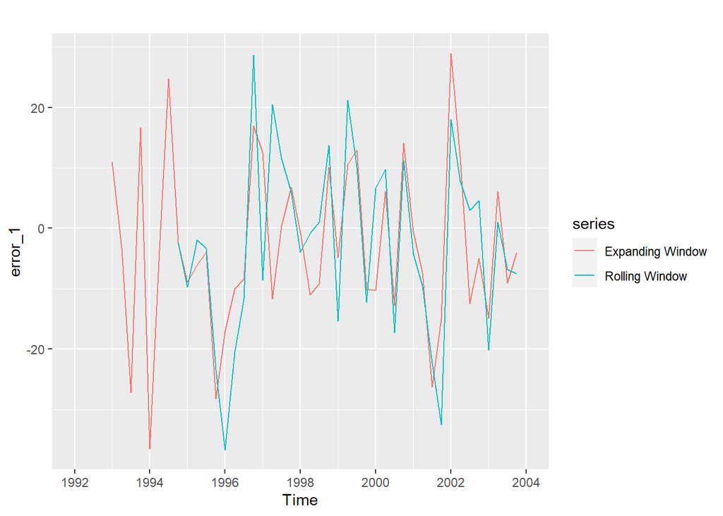

```r
autoplot(error_1, series = 'Expanding Window') +
  autolayer(error_2, series = 'Rolling Window')
```

### Print Errors and Calculate RMS

```r
print(error_1)
```

```
##             Qtr1        Qtr2        Qtr3        Qtr4
## 1992          NA          NA          NA          NA
## 1993  10.9994681  -3.3333799 -27.2179512  16.6514803
## 1994 -36.5331699  -3.5674448  24.7758818  -2.4698757
## 1995  -8.9171995  -6.1217090  -3.9328638 -28.2609077
## 1996 -17.0762275 -10.0511181  -8.4019273  16.9769159
## 1997  12.4992258 -11.7077739   0.3827561   6.8231105
## 1998  -0.6620310 -11.0055119  -9.1929234  10.0878399
## 1999  -4.8466439  10.5339997  12.9226223 -10.1239385
## 2000 -10.2710433   6.0727513 -12.8088931  14.1251618
## 2001  -0.5515436  -7.3714135 -26.2565636 -14.9792730
## 2002  28.9729900  11.8203374 -12.4810255  -4.9679291
## 2003 -14.9257752   6.0839384  -9.0073520  -4.0956933
## 2004          NA
```

```r
print(error_2)
```

```
##             Qtr1        Qtr2        Qtr3        Qtr4
## 1992          NA          NA          NA          NA
## 1993          NA          NA          NA          NA
## 1994          NA          NA          NA  -2.4698757
## 1995  -9.7189423  -1.8836104  -3.3288985 -23.4043708
## 1996 -36.6543385 -20.5036119 -11.7120541  28.7094572
## 1997  -8.5899001  20.4866216  11.4827974   5.9508989
## 1998  -3.9972267  -0.8409008   1.0115612  13.7324356
## 1999 -15.3545416  21.1638625  10.0610210 -12.2347096
## 2000   6.6241253   9.7034113 -17.2876661  11.2479506
## 2001  -4.2370184  -9.5386574 -22.3144835 -32.5405922
## 2002  18.0306713   7.8709836   2.9672318   4.5965070
## 2003 -20.1886283   0.9954022  -6.8386590  -7.5025336
## 2004          NA
```

```r
print(sqrt(mean(error_1^2, na.rm=TRUE)))
```

```
## [1] 14.17711
```

```r
print(sqrt(mean(error_2^2, na.rm=TRUE)))
```

```
## [1] 15.02045
```

## Example II

Source: https://robjhyndman.com/hyndsight/tscvexample/

### Plot the Time-series

Description

Total monthly scripts for pharmaceutical products falling under ATC code A10, as recorded by the Australian Health Insurance Commission.

See ?a10 for additional information

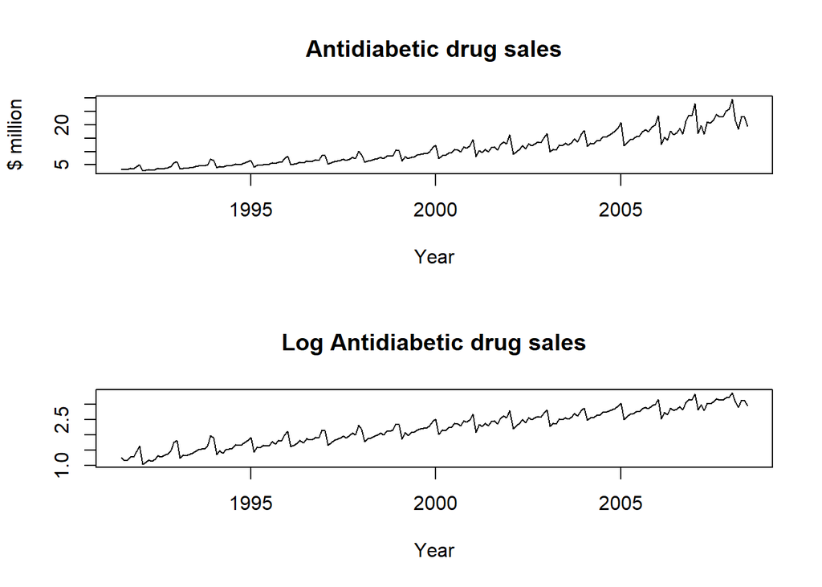

```r
par(mfrow=c(2,1))
plot(a10, ylab="$ million", xlab="Year", main="Antidiabetic drug sales")
plot(log(a10), ylab="", xlab="Year", main="Log Antidiabetic drug sales")
```

### CV - Expanding and Sliding Window

Applying time series CV and comparing 1-step, 2-step, ., 12-step forecasts using the Mean Absolute Error (MAE)

```r
k <- 60 # minimum data length for fitting a model
n <- length(a10) # Number of data points

p <- 12 ### Period
H <- 12 # Forecast Horiz
```

```r
defaultW <- getOption("warn")
options(warn = -1)

st <- tsp(a10)[1]+(k-2)/p #  gives the start time in time units,

mae_1 <- matrix(NA,n-k,H)
mae_2 <- matrix(NA,n-k,H)


for(i in 1:(n-k))
{


  ### One Month rolling forecasting
  # Expanding Window
  train_1 <- window(a10, end=st + i/p)  ## Window Length: k+i

  # Sliding Window - keep the training window of fixed length.
  # The training set always consists of k observations.
  train_2 <- window(a10, start=st+(i-k+1)/p, end=st+i/p) ## Window Length: k

  test <- window(a10, start=st + (i+1)/p, end=st + (i+H)/p) ## Window Length: H

  if (i<4) {
  cat(c("*** CV", i,":","len(Expanding Window):",length(train_1), "len(Sliding Window):",length(train_2), "len(Test):",length(test),'\n'  ))
  cat(c("*** TRAIN -  Expanding WIndow:",tsp(train_1)[1],'-',tsp(train_1)[2],'\n'))
  cat(c("*** TRAIN - Sliding WIndow:",tsp(train_2)[1],'-',tsp(train_2)[2],'\n'))
  cat(c("*** TEST:",tsp(test)[1],'-',tsp(test)[2],'\n'))
  cat("*************************** \n \n")
  }


  fit_1 <- Arima(train_1, order=c(3,0,1), seasonal=list(order=c(0,1,1), period=p),
                include.drift=TRUE, lambda=0, method="ML")
  fcast_1 <- forecast(fit_1, h=H)


  fit_2 <- Arima(train_2, order=c(3,0,1), seasonal=list(order=c(0,1,1), period=p),
                include.drift=TRUE, lambda=0, method="ML")
  fcast_2 <- forecast(fit_2, h=H)



  mae_1[i,1:length(test)] <- abs(fcast_1[['mean']]-test)
  mae_2[i,1:length(test)] <- abs(fcast_2[['mean']]-test)

}
```

```
## *** CV 1 : len(Expanding Window): 60 len(Sliding Window): 60 len(Test): 12
## *** TRAIN -  Expanding WIndow: 1991.5 - 1996.41666666667
## *** TRAIN - Sliding WIndow: 1991.5 - 1996.41666666667
## *** TEST: 1996.5 - 1997.41666666667
##
## *** CV 2 : len(Expanding Window): 61 len(Sliding Window): 60 len(Test): 12
## *** TRAIN -  Expanding WIndow: 1991.5 - 1996.5
## *** TRAIN - Sliding WIndow: 1991.58333333333 - 1996.5
## *** TEST: 1996.58333333333 - 1997.5
##
## *** CV 3 : len(Expanding Window): 62 len(Sliding Window): 60 len(Test): 12
## *** TRAIN -  Expanding WIndow: 1991.5 - 1996.58333333333
## *** TRAIN - Sliding WIndow: 1991.66666666667 - 1996.58333333333
## *** TEST: 1996.66666666667 - 1997.58333333333
##
```

```r
options(warn = defaultW)
```

### CV - Incremental Window

Another variation which is useful for large data sets isa to use a form of k-fold cross-validation where the training sets increment by several values at a time. For example, instead of incrementing by one observation in each iteration, we could shift the training set forward by 12 observations.

```r
k <- 60 # minimum data length for fitting a model
n <- length(a10) # Number of data points

p <- 12 ### Period
H <- 12 # Forecast Horiz
```

```r
# because this is based on fewer estimation steps, the results are much more volatile
st <- tsp(a10)[1]+(k-1)/p ### The same as before
mae_3 <- matrix(NA,p,H)

for(i in 1:H)
{
  # Expanding Window
  train <- window(a10, end=st + (i-1))
  test <- window(a10, start=st + (i-1) + 1/p, end=st + i) ## Window Length: H
  if (i<4) {
    cat(c("*** CV", i,":","len(train):",length(train), "len(Test):",length(test),'\n'  ))
    cat(c("*** TRAIN:",tsp(train)[1],'-',tsp(train)[2],'\n'))
    cat(c("*** TEST:",tsp(test)[1],'-',tsp(test)[2],'\n'))
    cat("*************************** \n \n")
    }


  fit_3 <- Arima(train, order=c(3,0,1), seasonal=list(order=c(0,1,1), period=p),
                include.drift=TRUE, lambda=0, method="ML")
  fcast_3 <- forecast(fit_3, h=H)

  mae_3[i,1:length(test)] <- abs(fcast_3[['mean']]-test)
}
```

```
## *** CV 1 : len(train): 60 len(Test): 12
## *** TRAIN: 1991.5 - 1996.41666666667
## *** TEST: 1996.5 - 1997.41666666667
##
## *** CV 2 : len(train): 72 len(Test): 12
## *** TRAIN: 1991.5 - 1997.41666666667
## *** TEST: 1997.5 - 1998.41666666667
##
## *** CV 3 : len(train): 84 len(Test): 12
## *** TRAIN: 1991.5 - 1998.41666666667
## *** TEST: 1998.5 - 1999.41666666667
##
```

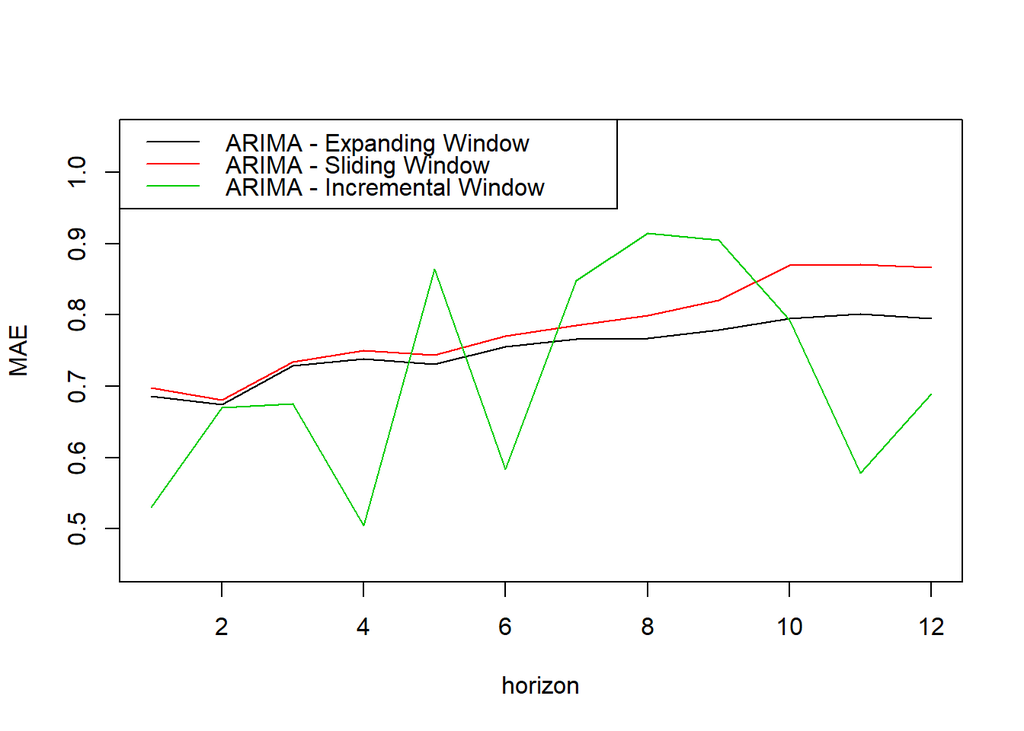

```r
win.graph(width=6, height=6,pointsize=12)
plot(1:12, colMeans(mae_1,na.rm=TRUE), type="l",col=1,xlab="horizon", ylab="MAE",
     ylim=c(0.45,1.05))
lines(1:12, colMeans(mae_2,na.rm=TRUE), type="l",col=2)
lines(1:12, colMeans(mae_3,na.rm=TRUE), type="l",col=3)
legend("topleft",legend=c("ARIMA - Expanding Window","ARIMA - Sliding Window", 'ARIMA - Incremental Window '),col=1:3,lty=1)
```

```r
mean(mae_1, na.rm=TRUE)
```

```
## [1] 0.7507238
```

```r
mean(mae_2, na.rm=TRUE)
```

```
## [1] 0.7811656
```

```r
mean(mae_3, na.rm=TRUE)
```

```
## [1] 0.7131129
```

## Example III - arima.boot

Compute the Bootstrap Estimates of an ARIMA Model

See ?arima.boot for additional information

### Plot the Time-series

Canadian hare data/ time series

Description

Annual number of hare data.

See ?hare for additional information

```r
data(hare)
```

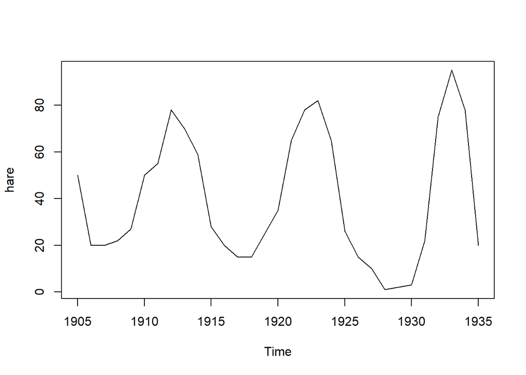

```r
plot(hare)
```

```r
BoxCox.lambda(hare)
```

```
## [1] 0.09549141
```

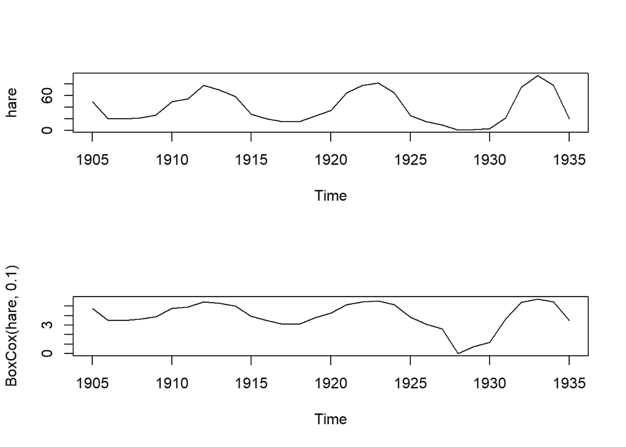

```r
par(mfrow=c(2,1))
plot(hare)
plot(BoxCox(hare, 0.1))
```

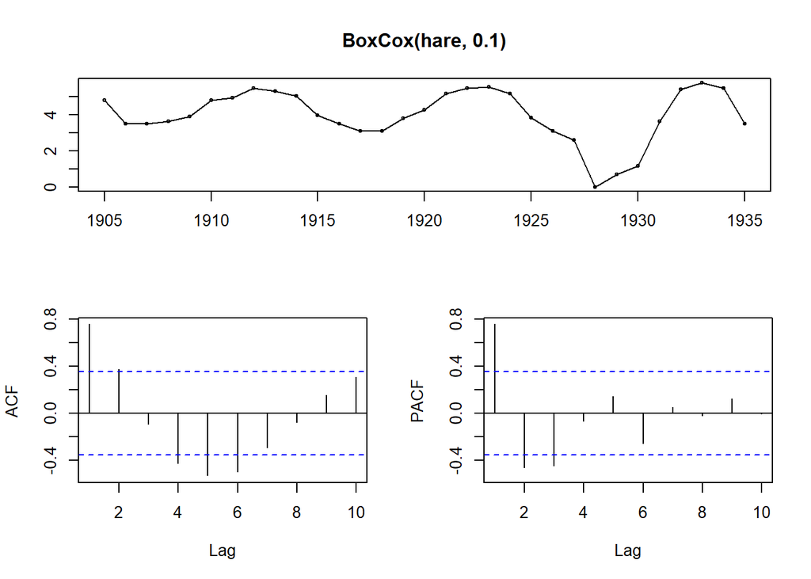

```r
tsdisplay(BoxCox(hare, 0.1))
```

### Apply arima.boot

```r
arima.hare=Arima(hare,order=c(3,0,0), lambda=0.1)


# number of bootstrap replicates ==> 50

boot.hare=arima.boot(arima.hare,B=50)
print(boot.hare)
```

```
##             ar1          ar2         ar3 intercept noise var
##  [1,] 0.7763290 -0.021465699 -0.40502633  4.343787 0.5959966
##  [2,] 0.8547324  0.185027547 -0.69531833  3.735817 0.3058900
##  [3,] 0.6174040  0.175109454 -0.47465302  3.824273 0.3461250
##  [4,] 0.7494642  0.089929044 -0.61732582  4.392733 0.3057732
##  [5,] 1.4070197 -0.697220700 -0.05944712  3.715719 0.5390052
##  [6,] 0.7100742  0.350557822 -0.69078872  4.115194 0.5951180
##  [7,] 1.1267389 -0.282667460 -0.25871324  3.642255 0.4664242
##  [8,] 0.9909547 -0.169839414 -0.42578167  3.546270 0.3040071
##  [9,] 1.1620078 -0.467129253 -0.18584806  3.703095 0.4199717
## [10,] 0.7665188  0.272326228 -0.58216674  3.761956 0.4641798
## [11,] 0.5064587  0.319653501 -0.61673036  3.801722 0.2521051
## [12,] 0.6727045  0.291035114 -0.49524325  4.456792 0.4045087
## [13,] 1.1096744 -0.341787626 -0.29164623  3.776241 0.4811290
## [14,] 1.2221643 -0.469534202 -0.25420657  3.688851 0.3450734
```

[output cut: 36 more lines]

```r
print(arima.hare)
```

```
## Series: hare
## ARIMA(3,0,0) with non-zero mean
## Box Cox transformation: lambda= 0.1
##
## Coefficients:
##          ar1     ar2      ar3    mean
##       0.9350  0.0085  -0.4801  3.9091
## s.e.  0.1649  0.2511   0.1659  0.2276
##
## sigma^2 estimated as 0.4985:  log likelihood=-32.29
## AIC=74.59   AICc=76.99   BIC=81.76
```

```r
apply(boot.hare,2,mean)
```

```
##         ar1         ar2         ar3   intercept   noise var
##  0.92352980 -0.03840316 -0.44677909  3.89452307  0.44958374
```

```r
apply(boot.hare,2,sd)
```

```
##       ar1       ar2       ar3 intercept noise var
## 0.1974339 0.2563420 0.1671539 0.2343732 0.1302464
```

```r
apply(boot.hare,2,quantile, c(.025,.975)) #2 indicates columns
```

```
##             ar1        ar2        ar3 intercept noise var
## 2.5%  0.5472816 -0.5366085 -0.7104038  3.557502 0.2854120
## 97.5% 1.3051700  0.3159871 -0.1688060  4.424707 0.7676606
```